# Assigment_Week2.Rmd

Michael

9/23/2020

# Assignment - Week 2

## Report

First that all, we need to get the data, so you should [download the document](https://github.com/rdpeng/RepData_PeerAssessment1)

Load the data using the r function *read.csv()*, creating a variable (ex. Step). Then, review the data with the R function *Head()*

```r
Step <- read.csv("activity.csv")
head(Step)
```

```
##   steps       date interval
## 1    NA 2012-10-01        0
## 2    NA 2012-10-01        5
## 3    NA 2012-10-01       10
## 4    NA 2012-10-01       15
## 5    NA 2012-10-01       20
## 6    NA 2012-10-01       25
```

### What is mean total number of steps taken per day?

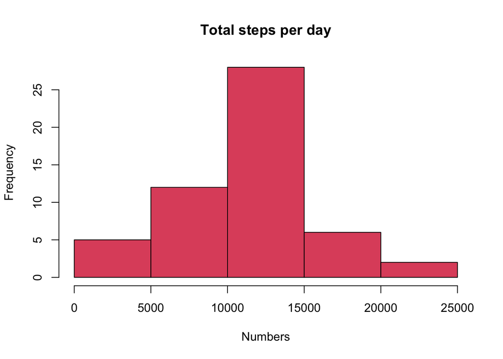

```r
# Calculate the total steps per day. Then plot the data
Totals <- aggregate(steps ~ date, Step, FUN=sum)
hist(Totals$steps, main = "Total steps per day", xlab = "Numbers", col=2)
```

Calculate and report the mean and median of the total number of steps taken per day.

```r
# You should remove the NA values, with the na.rm function.
Mean <- mean(Totals$steps, na.rm = TRUE)
Mean
```

```
## [1] 10766.19
```

```r
Median <- median(Totals$steps, na.rm = TRUE)
Median
```

```
## [1] 10765
```

### What is the average daily activity pattern?

Make a time series plot (i.e. type = “l”) of the 5-minute interval (x-axis) and the average number of steps taken, averaged across all days (y-axis)

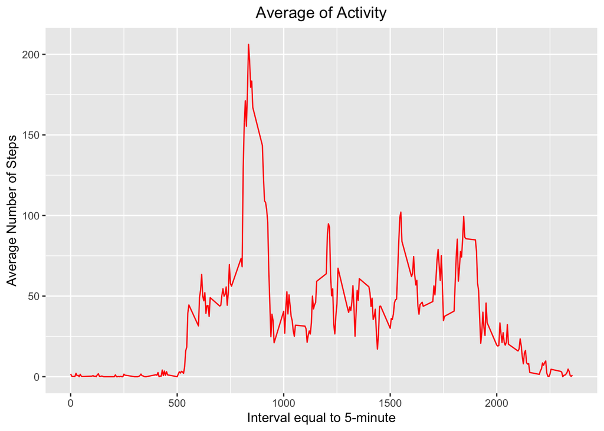

```r
library(ggplot2)
MeanStep <- aggregate(steps ~interval, Step, mean)
ggplot(data = MeanStep, aes(x = interval, y = steps)) +
  geom_line(colour= 'red') +
  ggtitle("Average of Activity") +
  xlab("Interval equal to 5-minute") +
  ylab("Average Number of Steps") +
  theme(plot.title = element_text(hjust = 0.5))
```

Which 5-minute interval, on average across all the days in the dataset, contains the maximum number of steps?

```r
Max <- MeanStep[which.max(MeanStep$steps),]
Max
```

```
##     interval    steps
## 104      835 206.1698
```

### Imputing missing values

Note that there are a number of days/intervals where there are missing values (coded as NA). The presence of missing days may introduce bias into some calculations or summaries of the data.

```r
TotalMissing <- is.na(Step$steps)
```

**Devise a strategy for filling in all of the missing values in the dataset.** I’ll choose to use the mean for the 5-day interval

```r
#Create a new dataset that is equal to the original dataset but with the missing data filled in.
NewData <- transform(Step,
                     steps = ifelse(is.na(Step$steps),
                            MeanStep$steps[match(Step$interval,
                                                 MeanStep$interval)],
                            Step$steps))
```

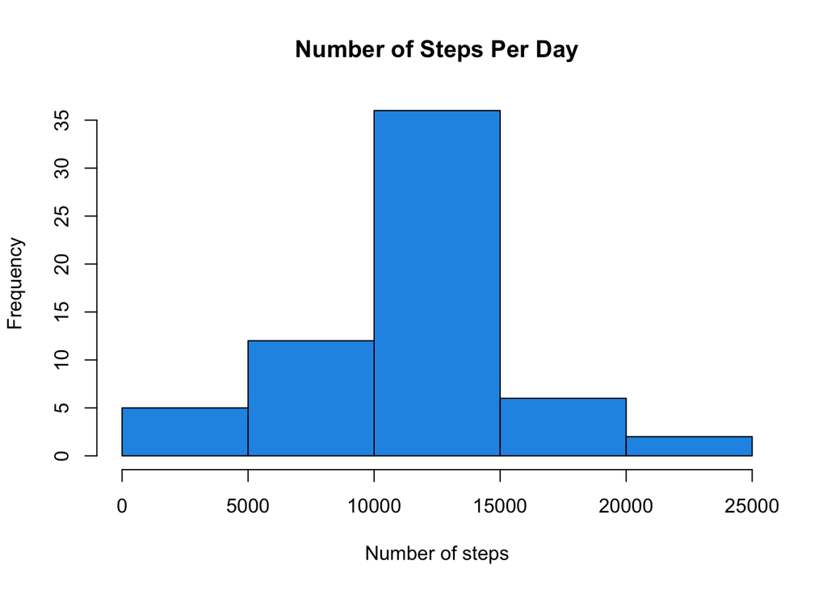

```r
StepByDay <- aggregate(steps ~ date, NewData, FUN=sum)
hist(StepByDay$steps,
     main= "Number of Steps Per Day",
     xlab= "Number of steps",
     col = 4)
```

```r
MeanSteps2 <- mean(StepByDay$steps, na.rm = TRUE)
MedSteps2 <- median(StepByDay$steps, na.rm = TRUE)
Meandif = MeanSteps2 - MeanStep
Mediff = MedSteps2 - Median
diffTotal = sum(StepByDay$steps) - sum(Totals$steps)
diffTotal
```

```
## [1] 86129.51
```

### Are there differences in activity patterns between weekdays and weekends?

Create a new factor variable in the dataset with two levels – “weekday” and “weekend” indicating whether a given date is a weekday or weekend day.

```r
DayType <- function(date) {
  day <- weekdays(date)
  if (day %in% c('Monday', 'Tuesday', 'Wednesday', 'Thursday', 'Friday'))
      return ("weekeday")
  else if (day %in% c('Saturday', 'Sunday'))
      return ("weekend")
  else
      stop ("Invalid Date Format.")
}
StepByDay$date <- as.Date(StepByDay$date)
StepByDay$day <- sapply(StepByDay$date, FUN = DayType)
```

[figure not shown]

```r
meanStepsByDay <- aggregate(steps ~ interval + date, NewData, mean)
ggplot(data = meanStepsByDay, aes(x = interval, y = steps)) +
  geom_line(colour= 'blue') +
  facet_grid(date ~ .) +
  ggtitle("Average Daily Activity") +
  xlab("5-minute Interval") +
  ylab("Average Number of Steps") +
  theme(plot.title = element_text(hjust = 0.5))
```